# 政治学方法論1-課題3

氏名：和田健太郎(WADA Kentaro)

提出日：2014年10月21日(火)

### 問題1

#### 階乗を計算する関数を作りなさい

#### *R には元々 factorial() 関数があるが、それは使わない

#### 手順は以下の通りである。

#### 1) 階乗を求める関数を任意の名前（wada.factorial）で作成する

#### 2) 引数をn、返り値をanswerとする

#### 3) 引数は1以上、0、0未満、以上3つに分類され、if関数を用いてそれぞれの場合の返り値を設定する

```r
wada.factorial <- function(n) {# factorial関数と同じ機能をもつ関数をwada.factorialという名前で保存する
  ## 引数 = n
  ## 返り値 = answer
  answer <- 1 # 返り値を指定する
  if(n < 0) {# 引数が0未満であればエラーメッセージを表示する
    print("引数が0未満のためエラーです")
    }

  else if(n == 0){# 引数が0ならば返り値は1とする
    return(1)
    }
  else{ # forループを使って階乗を計算する
    for(i in n:1){
      answer <- answer * i # iと前の直前のanswerを掛ける
      }
    return(answer) #結果を返す
    }
}
```

#### 4) 確認のため、いくつか引数を当てはめてみる

```r
wada.factorial(6) # 6の階乗を計算してみる
```

```
## [1] 720
```

```r
wada.factorial(-2) # -2の階乗を計算してみる
```

```
## [1] "引数が0未満のためエラーです"
```

```r
wada.factorial(0) # 0の階乗を計算してみる
```

```
## [1] 1
```

#### 5) さらに確認のため、関数（factorial）と結果を比較する

```r
factorial(10) == wada.factorial(10)
```

```
## [1] TRUE
```

### 問題2

#### 自分で作った階乗の関数を利用して、組み合わせを計算する関数を作りなさい

#### ＊R には元々choose() 関数があるが、それは使わない

#### 手順は以下の通りである。

#### 1) 組み合わせを求める関数を任意の名前（wada.choose）で作成する

#### 2) 引数をnとkに、返り値をanswerとする。ただし、nは全体の数を、kは全体から選ぶ数を意味する

#### 3) 引数がk > nとなる場合とそれ以外の場合に分類する

#### 4) 引数がk > nとなる場合、返り値はoとする

#### 5) それ以外ならば、問題1で生成したwada.factorialを活用し、返り値を計算する

```r
wada.choose <- function(n, k){# choose関数と同じ機能をもつ関数をwada.chooseという名前で保存する
## 引数 = n, k
## 返り値 = answer

  if(k >n){# k（全体から選ぶ数）が n（全体の数）より大きいならば"ゼロ"を返す
    return(0)
    }

  else {# それ以外の場合は組み合わせの結果を計算して、結果を返す
    answer <- wada.factorial(n) / (wada.factorial(k) * wada.factorial(n-k)) # 問題1で作成したwada.factorialを活用して、組み合わせを求める公式を当てはめる
    return(answer)
    }
}
```

#### 6) 確認のため、いくつか引数を当てはめてみる

```r
wada.choose(100, 3) # 100個から3個を選ぶ
```

```
## [1] 161700
```

```r
wada.choose(30, 40) # 30個から40個を選ぶ
```

```
## [1] 0
```

#### 7) さらに確認のため、関数（choose）と結果を比較する

```r
choose(100, 3) == wada.choose(100, 3)
```

```
## [1] TRUE
```

### 問題3

#### 自分で作った組み合わせの関数を利用して、二項分布の確率質量を求める関数を作りなさい

#### ＊Rには元々 dbinom() 関数があるが、それは使わない

#### 手順は以下の通りである。

#### 1) 二項分布の確率質量を求める関数を任意の名前（wada.dbinom）で作成する

#### 2) 引数をnとkとpに、返り値をanswerとする。ただし、nは成功回数を、kはベルヌーイ試行の回数を、pはベルヌーイ試行における成功確率を意味する

#### 3) 問題2で作成したwada.chooseを利用して、返り値を計算する

```r
wada.dbinom <- function(n, k, p){# dbinom関数と同じ機能をもつ関数をwada.dbinomという名前で保存する
## 引数 n = 成功回数
## 引数 k = ベルヌーイ試行の回数
## 引数 p = ベルヌーイ試行における成功確率
## 返り値 = answer

  answer <- wada.choose(k, n) * p^n * (1-p) ^ (k-n) # 問題2で作成したwada.chooseを活用して、二項分布の確率質量を求める公式を当てはめる

  return(answer)

}
```

#### 4) 確認のため引数を当てはめてみる

```r
wada.dbinom(3, 10, .3 ) # 成功回数3回、試行回数10回、成功確率30%
```

```
## [1] 0.2668279
```

#### 5) さらに確認のため、関数（dbinom）と結果を比較する

```r
dbinom(3, 10, .3) == wada.dbinom(3, 10, .3)
```

```
## [1] FALSE
```

#### 6) 比較の結果、FALSEが帰ってきた。関数（dbinom）のみで返り値を確認する

```r
dbinom(3, 10, .3)
```

```
## [1] 0.2668279
```

#### 7) dbinom関数とwada.dbinom関数の答えは小数点7桁までは同じと言える。FALSEが帰ってきた理由として、小数点7桁以下のどこかで微妙な違いがあることが考えられる

### 問題4

#### 自分で作った二項分布の関数を使い、n が 2, 3, 5, 10 の場合について、確率質量を図示しなさい。p の値については任意とする。ただし、2 つ以上の p で図を作りなさい。その際、for() ループ を少なくとも 1 回使いなさい。

#### 手順は以下の通りである。

#### 1) 二項分布の確率質量を記入するデータフレームを2つ作成する

#### 2) 第1のデータフレームはループ文内で使用し、第1行に必要情報を入力するため、欠損値で構成する

#### 3) 第2のデータフレームは完成版として使用し、第1のデータフレームと結合するため、欠損値ではなくNULLで構成する

```r
# 第1のデータフレームを作成
loop.data.frame <- data.frame(p=NA, n=NA, k=NA, result=NA)
# 第2のデータフレームを作成
completed.data.frame <- data.frame(p=NULL, n=NULL, k=NULL, result=NULL)
```

#### 4) 成功確率をp, 試行回数をn, 成功回数をkとし、それぞれに対してループを使うため３つのfor文を用いる。ただし、これらのforループは独立しているわけではなく、3重構造になっている。

#### 5) 3つ目のfor文の中で第1データフレームにp, n, k, 確率質量を書き込む

#### 6) rbind関数を使用して第2データフレームの最後の行に追加する。確率質量は問題3で作成したwada.dbinomを利用する。

```r
for(p in c(0.3, 0.6)){         # p = o.3 / 0.6 とする
  for(i in c(2, 3, 5, 10)){    # n = 2, 3, 5, 10 とする
    for(j in 0:i){             # k = 0 ~ n とする

      # p, n, k, と結果を第1データフレームに入れる
      loop.data.frame[1, ] <- c(paste("p =", p), paste("n =", i), j, wada.dbinom(j, i, p))

      # 第1・第2データフレームを結合する
      completed.data.frame <- rbind(completed.data.frame, loop.data.frame)
    }
  }
}
```

#### 7) 第2データフレームの中身を確認する

```r
# 最初の6行を表示する
head(completed.data.frame)
```

```
##         p     n k result
## 1 p = 0.3 n = 2 0   0.49
## 2 p = 0.3 n = 2 1   0.42
## 3 p = 0.3 n = 2 2   0.09
## 4 p = 0.3 n = 3 0  0.343
## 5 p = 0.3 n = 3 1  0.441
## 6 p = 0.3 n = 3 2  0.189
```

```r
# 最後の6行を表示する
tail(completed.data.frame)
```

```
##          p      n  k       result
## 43 p = 0.6 n = 10  5 0.2006581248
## 44 p = 0.6 n = 10  6  0.250822656
## 45 p = 0.6 n = 10  7  0.214990848
## 46 p = 0.6 n = 10  8  0.120932352
## 47 p = 0.6 n = 10  9  0.040310784
## 48 p = 0.6 n = 10 10 0.0060466176
```

#### 8) 第2データフレームをggplotでグラフ化すると*n=10*, *n=2*, *n=3*, *n=5*の順番で表示されるため、n列のデータをfactor型へ変換し、順序付けする。なぜなら、数値データではなく文字データとして書き込まれているからである。

```r
# nの順序を並べ替える
completed.data.frame$n <- factor(completed.data.frame$n,
                             levels = c("n = 2", "n = 3", "n = 5", "n = 10"))
```

#### 9) ggplot2を読み込んでおく

```r
# ggplot2を呼び込む
require(ggplot2)
```

#### 10) 成功確率を0.3と0.6で表示するため、1行目から24行目はp = 0.3で、25行目から48行行目はp = 0.6を用いる。

```r
# データセットを読み込むためのオブジェクトを作成する
bar.graph1 <- ggplot(data = completed.data.frame[1:24, ])
bar.graph2 <- ggplot(data = completed.data.frame[25:48, ])
```

#### 11) 準備が整ったので、オプションをつけて P = 0.3 を表示する

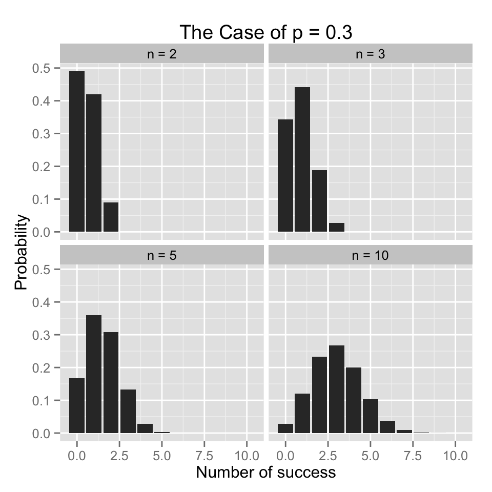

```r
# p = 0.3をnごとに分けて表示する
bar.graph1 + geom_bar(aes(x = as.integer(k), y = as.numeric(result)), stat="identity") +
             facet_wrap(~n) + ylab("Probability") + xlab("Number of success") +
             ggtitle("The Case of p = 0.3")
```

#### 12) p = 0.6を、オプションをつけて表示する

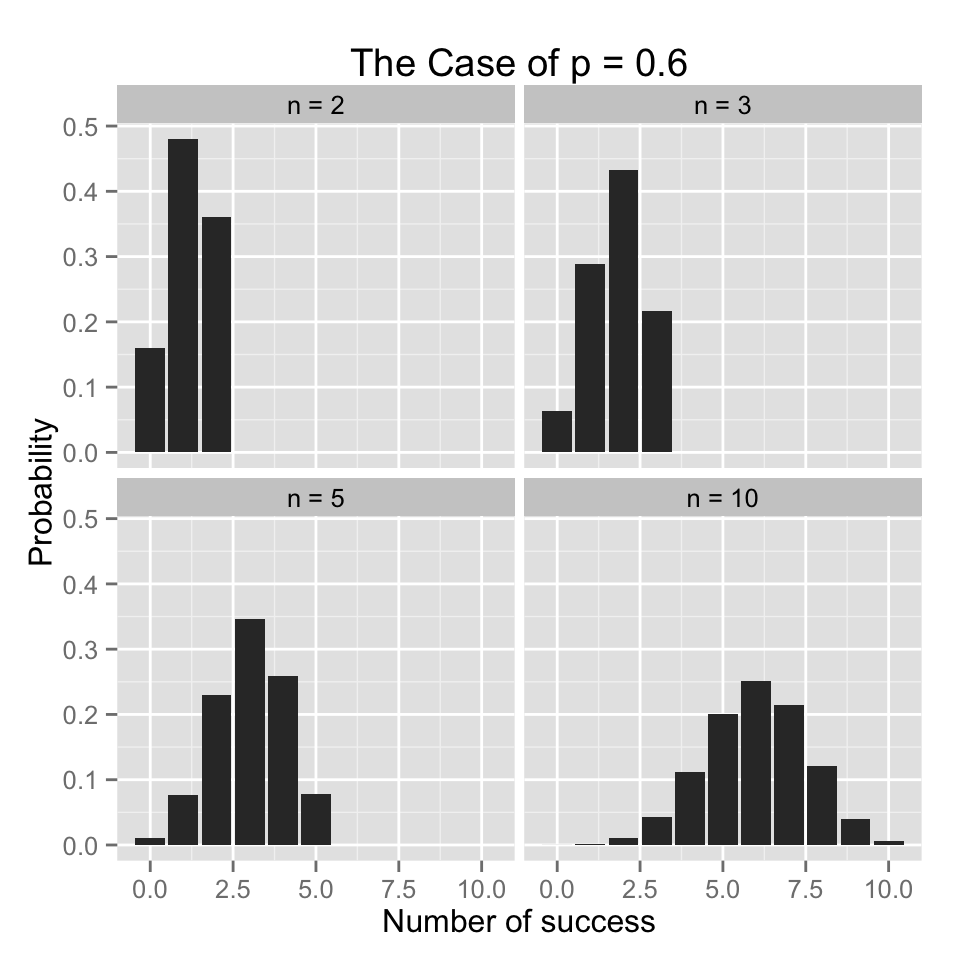

```r
# p = 0.3をnごとに分けて表示する
bar.graph2 + geom_bar(aes(x = as.integer(k), y = as.numeric(result)), stat="identity") +
             facet_wrap(~n) + ylab("Probability") + xlab("Number of success") +
             ggtitle("The Case of p = 0.6")
```